# AI-powered Bayesian inference: classification part, exploratory analysis

DSC536 project, PAD-UFES-20 skin lesion data

26 November 2026

This document is the exploratory analysis of the cleaned PAD-UFES-20 data used in the classification part of the project. The input is `data/pad_clean.csv`, produced by `classification/01_clean.R`, with one lesion per patient. Tables and plots are also saved in `classification/results/eda/`.

What it looks at:

1. Class balance.
2. Numeric features (age, Fitzpatrick skin type, diameters): summaries and boxplots by class, and their correlations.
3. Categorical features: the one-hot columns are turned back into one variable each, and the share of every level within each class is shown as a table and a heatmap.
4. A simple test per feature of whether it differs between classes (Kruskal-Wallis for numeric, chi-square for categorical). These are descriptive only, with no correction for multiple testing.

```r
IN_FILE <- file.path(ROOT, "data", "pad_clean.csv")
OUT_DIR <- file.path(ROOT, "classification", "results", "eda")
dir.create(OUT_DIR, showWarnings = FALSE, recursive = TRUE)
set.seed(536)

if (!file.exists(IN_FILE)) stop("Run classification/01_clean.R first: ", IN_FILE, " not found")
save_tab <- function(x, name) write.csv(x, file.path(OUT_DIR, name), row.names = FALSE)
# draws a plot into a png in OUT_DIR, then again for this document
save_plot <- function(draw, file, width, height) {
  png(file.path(OUT_DIR, file), width = width, height = height, res = 150)
  draw()
  dev.off()
  draw()
}

d <- read.csv(IN_FILE, stringsAsFactors = FALSE, check.names = FALSE)

# classes ordered by size, used in every table and plot
CLASSES <- names(sort(table(d$diagnostic), decreasing = TRUE))
d$diagnostic <- factor(d$diagnostic, levels = CLASSES)

NUM_VARS <- c("age", "fitspatrick", "diameter_1", "diameter_2")
LOGICALS <- c("smoke", "drink", "pesticide", "skin_cancer_history", "cancer_history",
              "has_piped_water", "has_sewage_system")
# reference level of each one-hot group (see section 7 of 01_clean.R)
REFS <- c(gender = "FEMALE", region = "FACE", background_father = "POMERANIA",
          background_mother = "POMERANIA", itch = "True", grew = "True", hurt = "False",
          changed = "False", bleed = "False", elevation = "True")

BLUE <- "#257de0"
RAMP <- colorRampPalette(c("#ffffff", "#cce3fd", "#84b9f3", "#338ced", "#1b64be", "#0e3d7e"))(100)
INK  <- "#191919"
GREY <- "#666666"
```

# 1 Data check

```r
data.frame(rows = nrow(d), unique_patients = length(unique(d$patient_id)),
           missing_values = sum(is.na(d)))
```

```
##   rows unique_patients missing_values
## 1  794             794              0
```

```r
stopifnot(!anyNA(d), !any(duplicated(d$patient_id)))
```

The categorical features are stored as one-hot columns. For the summaries below each group is turned back into a single variable, where a row with no 1 in the group takes the reference level.

```r
cat_df <- data.frame(row.names = seq_len(nrow(d)))
for (v in names(REFS)) {
  cols <- grep(paste0("^", v, "_"), names(d), value = TRUE)
  M <- as.matrix(d[cols])
  stopifnot(all(rowSums(M) <= 1))
  lev <- sub(paste0("^", v, "_"), "", cols)
  x <- rep(REFS[[v]], nrow(d))
  hit <- rowSums(M) == 1
  x[hit] <- lev[max.col(M[hit, , drop = FALSE])]
  cat_df[[v]] <- factor(x, levels = c(REFS[[v]], lev))
}
for (v in LOGICALS) cat_df[[v]] <- factor(ifelse(d[[v]] == 1, "True", "False"), levels = c("False", "True"))
```

# 2 Class balance

```r
cc <- table(d$diagnostic)
class_tab <- data.frame(class = names(cc), n = as.integer(cc), pct = round(100 * as.numeric(cc) / nrow(d), 1))
kable(class_tab)
```

| class | n | pct |
| --- | --- | --- |
| BCC | 449 | 56.5 |
| ACK | 137 | 17.3 |
| SCC | 111 | 14.0 |
| NEV | 46 | 5.8 |
| MEL | 31 | 3.9 |
| SEK | 20 | 2.5 |

```r
save_tab(class_tab, "class_counts.csv")
```

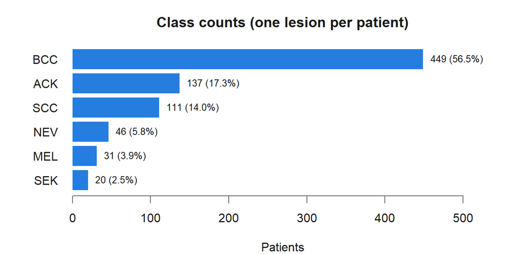

```r
save_plot(function() {
  par(mar = c(4, 5, 3, 1), fg = GREY, col.axis = INK, col.lab = INK)
  bp <- barplot(rev(class_tab$n), names.arg = rev(class_tab$class), horiz = TRUE, las = 1,
                col = BLUE, border = NA, xlim = c(0, max(class_tab$n) * 1.2),
                xlab = "Patients", main = "Class counts (one lesion per patient)", col.main = INK)
  text(rev(class_tab$n), bp, sprintf("%d (%.1f%%)", rev(class_tab$n), rev(class_tab$pct)),
       pos = 4, cex = 0.8, col = INK)
}, "class_counts.png", width = 1050, height = 525)
```

The classes are very unbalanced. BCC is 56.5% of the patients, while MEL (31 patients, 3.9%) and SEK (20 patients, 2.5%) are rare. With 15% of the data used as the labelled set, MEL and SEK will have only about 4 and 3 labelled patients. A model that always predicts BCC already reaches about 56% accuracy, so we report balanced accuracy and macro F1 together with accuracy. BCC, SCC and MEL are cancers, ACK is precancerous, and NEV and SEK are benign.

# 3 Numeric features

```r
num_sum <- function(x) c(n = length(x), mean = mean(x), sd = sd(x), min = min(x),
                         q1 = unname(quantile(x, 0.25)), median = median(x),
                         q3 = unname(quantile(x, 0.75)), max = max(x))
num_tab <- do.call(rbind, lapply(NUM_VARS, function(v) {
  groups <- c(list(All = d[[v]]), split(d[[v]], d$diagnostic))
  out <- t(sapply(groups, num_sum))
  data.frame(variable = v, class = rownames(out), round(out, 2), row.names = NULL)
}))
kable(num_tab)
```

| variable | class | n | mean | sd | min | q1 | median | q3 | max |
| --- | --- | --- | --- | --- | --- | --- | --- | --- | --- |
| age | All | 794 | 62.22 | 14.75 | 13 | 53.25 | 63.0 | 73.00 | 94 |
| age | BCC | 449 | 62.26 | 13.56 | 22 | 53.00 | 62.0 | 72.00 | 94 |
| age | ACK | 137 | 63.90 | 11.63 | 20 | 56.00 | 65.0 | 71.00 | 90 |
| age | SCC | 111 | 68.95 | 13.06 | 32 | 60.50 | 69.0 | 79.00 | 94 |
| age | NEV | 46 | 39.54 | 17.77 | 13 | 27.00 | 36.0 | 52.75 | 81 |
| age | MEL | 31 | 59.29 | 11.60 | 30 | 53.50 | 58.0 | 67.50 | 82 |
| age | SEK | 20 | 69.00 | 15.14 | 21 | 63.75 | 69.0 | 80.00 | 90 |
| fitspatrick | All | 794 | 2.29 | 0.75 | 1 | 2.00 | 2.0 | 3.00 | 6 |
| fitspatrick | BCC | 449 | 2.22 | 0.70 | 1 | 2.00 | 2.0 | 3.00 | 5 |
| fitspatrick | ACK | 137 | 2.39 | 0.74 | 1 | 2.00 | 2.0 | 3.00 | 5 |
| fitspatrick | SCC | 111 | 2.25 | 0.72 | 1 | 2.00 | 2.0 | 3.00 | 5 |
| fitspatrick | NEV | 46 | 2.61 | 0.88 | 1 | 2.00 | 2.5 | 3.00 | 5 |
| fitspatrick | MEL | 31 | 2.32 | 0.65 | 1 | 2.00 | 2.0 | 3.00 | 4 |
| fitspatrick | SEK | 20 | 2.70 | 1.30 | 1 | 2.00 | 2.0 | 3.25 | 6 |
| diameter_1 | All | 794 | 11.56 | 8.74 | 0 | 6.00 | 10.0 | 15.00 | 90 |
| diameter_1 | BCC | 449 | 11.37 | 8.21 | 0 | 7.00 | 10.0 | 14.00 | 90 |
| diameter_1 | ACK | 137 | 10.29 | 6.28 | 1 | 6.00 | 10.0 | 13.00 | 50 |
| diameter_1 | SCC | 111 | 13.24 | 10.04 | 0 | 8.00 | 11.0 | 15.00 | 90 |
| diameter_1 | NEV | 46 | 10.96 | 14.88 | 2 | 5.00 | 7.0 | 10.00 | 89 |
| diameter_1 | MEL | 31 | 15.97 | 8.49 | 5 | 10.00 | 14.0 | 20.00 | 40 |
| diameter_1 | SEK | 20 | 9.50 | 5.31 | 3 | 5.00 | 8.0 | 15.00 | 19 |
| diameter_2 | All | 794 | 8.63 | 6.04 | 0 | 5.00 | 7.0 | 10.00 | 70 |
| diameter_2 | BCC | 449 | 8.50 | 6.16 | 0 | 5.00 | 7.0 | 10.00 | 70 |
| diameter_2 | ACK | 137 | 8.01 | 5.18 | 1 | 5.00 | 7.0 | 10.00 | 48 |
| diameter_2 | SCC | 111 | 9.95 | 5.53 | 0 | 6.00 | 9.0 | 13.00 | 33 |
| diameter_2 | NEV | 46 | 6.85 | 6.70 | 2 | 3.25 | 4.5 | 7.00 | 40 |
| diameter_2 | MEL | 31 | 12.23 | 7.46 | 3 | 7.50 | 10.0 | 15.00 | 34 |
| diameter_2 | SEK | 20 | 7.00 | 4.26 | 2 | 4.00 | 5.0 | 9.25 | 15 |

```r
save_tab(num_tab, "numeric_summary.csv")
```

Spearman correlations between the numeric features:

```r
num_cor <- round(cor(d[NUM_VARS], method = "spearman"), 2)
kable(num_cor)
```

|  | age | fitspatrick | diameter_1 | diameter_2 |
| --- | --- | --- | --- | --- |
| age | 1.00 | -0.16 | 0.11 | 0.14 |
| fitspatrick | -0.16 | 1.00 | -0.06 | -0.07 |
| diameter_1 | 0.11 | -0.06 | 1.00 | 0.89 |
| diameter_2 | 0.14 | -0.07 | 0.89 | 1.00 |

```r
save_tab(data.frame(variable = rownames(num_cor), num_cor, row.names = NULL), "numeric_correlation.csv")
```

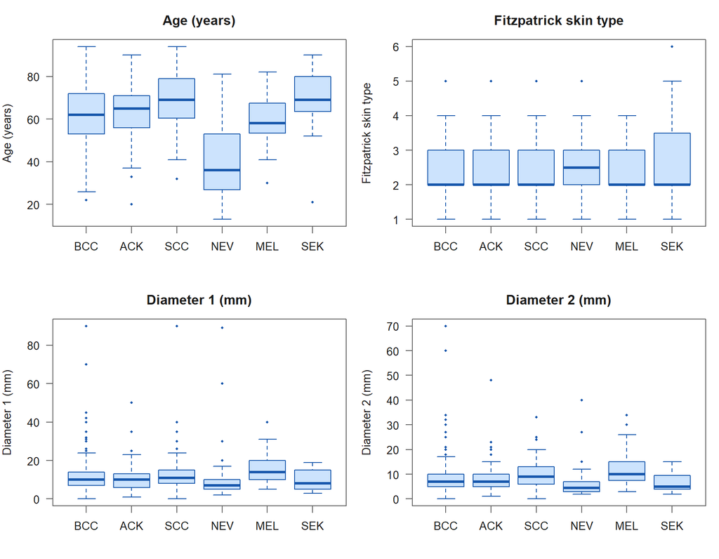

```r
labs <- c(age = "Age (years)", fitspatrick = "Fitzpatrick skin type",
          diameter_1 = "Diameter 1 (mm)", diameter_2 = "Diameter 2 (mm)")
save_plot(function() {
  par(mfrow = c(2, 2), mar = c(4, 4, 3, 1), fg = GREY, col.axis = INK, col.lab = INK)
  for (v in NUM_VARS) {
    boxplot(d[[v]] ~ d$diagnostic, col = "#cce3fd", border = "#1757ac", outcol = "#1757ac",
            pch = 16, cex = 0.5, xlab = "", ylab = labs[[v]], main = labs[[v]], col.main = INK, las = 1)
  }
}, "numeric_by_class.png", width = 1350, height = 1050)
```

Age separates the classes more than any other feature. NEV patients are much younger (median 36) than the other classes (medians 58 to 69), and SCC and SEK patients are the oldest (median 69). MEL lesions are the largest (median 14 x 10 mm), and NEV lesions are the smallest in the second diameter (median 4.5 mm). Most patients have Fitzpatrick type 2 or 3 in every class, so this feature carries little information. The two diameters are strongly correlated (Spearman 0.89) and describe almost the same thing. A few lesions have a diameter of 0 mm and a few reach 90 mm, which look like recording errors.

# 4 Categorical features

Each cell is the percentage of patients in that class with the given level, so every column of a variable sums to 100.

```r
cat_tab <- do.call(rbind, lapply(names(cat_df), function(v) {
  tab <- table(cat_df[[v]], d$diagnostic)
  share <- prop.table(tab, 2)
  data.frame(variable = v, level = rownames(tab), n_all = as.integer(rowSums(tab)),
             pct_all = round(100 * rowSums(tab) / nrow(d), 1),
             round(100 * unclass(share), 1), row.names = NULL, check.names = FALSE)
}))
kable(cat_tab)
```

| variable | level | n_all | pct_all | BCC | ACK | SCC | NEV | MEL | SEK |
| --- | --- | --- | --- | --- | --- | --- | --- | --- | --- |
| gender | FEMALE | 416 | 52.4 | 50.3 | 55.5 | 47.7 | 67.4 | 51.6 | 70 |
| gender | MALE | 378 | 47.6 | 49.7 | 44.5 | 52.3 | 32.6 | 48.4 | 30 |
| region | FACE | 209 | 26.3 | 32.5 | 18.2 | 17.1 | 17.4 | 9.7 | 40 |
| region | FOREARM | 100 | 12.6 | 7.6 | 29.9 | 18.0 | 0.0 | 12.9 | 5 |
| region | CHEST | 99 | 12.5 | 15.4 | 6.6 | 9.0 | 6.5 | 3.2 | 35 |
| region | NOSE | 88 | 11.1 | 17.1 | 4.4 | 4.5 | 0.0 | 0.0 | 0 |
| region | BACK | 77 | 9.7 | 8.5 | 2.9 | 6.3 | 39.1 | 29.0 | 5 |
| region | ARM | 59 | 7.4 | 4.5 | 11.7 | 11.7 | 8.7 | 16.1 | 5 |
| region | NECK | 36 | 4.5 | 5.6 | 2.2 | 4.5 | 0.0 | 6.5 | 5 |
| region | EAR | 32 | 4.0 | 4.9 | 1.5 | 5.4 | 0.0 | 3.2 | 5 |
| region | HAND | 31 | 3.9 | 1.1 | 10.9 | 9.0 | 2.2 | 0.0 | 0 |
| region | THIGH | 31 | 3.9 | 1.8 | 5.1 | 6.3 | 8.7 | 16.1 | 0 |
| region | FOOT | 12 | 1.5 | 0.0 | 2.9 | 3.6 | 8.7 | 0.0 | 0 |
| region | LIP | 11 | 1.4 | 1.1 | 1.5 | 2.7 | 2.2 | 0.0 | 0 |
| region | ABDOMEN | 6 | 0.8 | 0.0 | 1.5 | 0.9 | 4.3 | 3.2 | 0 |
| region | SCALP | 3 | 0.4 | 0.0 | 0.7 | 0.9 | 2.2 | 0.0 | 0 |
| background_father | POMERANIA | 276 | 34.8 | 37.2 | 34.3 | 27.9 | 28.3 | 35.5 | 35 |
| background_father | GERMANY | 253 | 31.9 | 33.2 | 31.4 | 33.3 | 26.1 | 25.8 | 20 |
| background_father | ITALY | 126 | 15.9 | 14.0 | 16.1 | 18.9 | 26.1 | 22.6 | 5 |
| background_father | UNK | 60 | 7.6 | 6.2 | 8.0 | 6.3 | 15.2 | 9.7 | 20 |
| background_father | BRAZIL | 51 | 6.4 | 5.8 | 5.8 | 9.9 | 4.3 | 0.0 | 20 |
| background_father | OTHER | 18 | 2.3 | 2.7 | 1.5 | 1.8 | 0.0 | 6.5 | 0 |
| background_father | NETHERLANDS | 10 | 1.3 | 0.9 | 2.9 | 1.8 | 0.0 | 0.0 | 0 |
| background_mother | POMERANIA | 282 | 35.5 | 38.3 | 34.3 | 28.8 | 30.4 | 32.3 | 35 |
| background_mother | GERMANY | 260 | 32.7 | 33.2 | 34.3 | 36.0 | 21.7 | 32.3 | 20 |
| background_mother | ITALY | 124 | 15.6 | 13.8 | 16.8 | 17.1 | 26.1 | 19.4 | 10 |
| background_mother | UNK | 53 | 6.7 | 5.8 | 4.4 | 6.3 | 15.2 | 9.7 | 20 |
| background_mother | BRAZIL | 43 | 5.4 | 4.0 | 6.6 | 8.1 | 6.5 | 3.2 | 15 |
| background_mother | NETHERLANDS | 12 | 1.5 | 2.0 | 0.7 | 1.8 | 0.0 | 0.0 | 0 |
| background_mother | OTHER | 10 | 1.3 | 1.6 | 1.5 | 0.9 | 0.0 | 0.0 | 0 |
| background_mother | PORTUGAL | 10 | 1.3 | 1.3 | 1.5 | 0.9 | 0.0 | 3.2 | 0 |
| itch | True | 539 | 67.9 | 75.1 | 73.0 | 78.4 | 10.9 | 16.1 | 25 |
| itch | False | 249 | 31.4 | 24.9 | 25.5 | 18.9 | 87.0 | 83.9 | 75 |
| itch | UNK | 6 | 0.8 | 0.0 | 1.5 | 2.7 | 2.2 | 0.0 | 0 |
| grew | True | 313 | 39.4 | 45.2 | 21.9 | 36.0 | 23.9 | 64.5 | 45 |
| grew | UNK | 284 | 35.8 | 40.8 | 4.4 | 45.0 | 58.7 | 32.3 | 40 |
| grew | False | 197 | 24.8 | 14.0 | 73.7 | 18.9 | 17.4 | 3.2 | 15 |
| hurt | False | 582 | 73.3 | 63.7 | 86.9 | 74.8 | 93.5 | 100.0 | 100 |
| hurt | True | 204 | 25.7 | 35.6 | 12.4 | 24.3 | 0.0 | 0.0 | 0 |
| hurt | UNK | 8 | 1.0 | 0.7 | 0.7 | 0.9 | 6.5 | 0.0 | 0 |
| changed | False | 437 | 55.0 | 51.7 | 94.2 | 42.3 | 30.4 | 12.9 | 55 |
| changed | UNK | 279 | 35.1 | 40.8 | 1.5 | 45.0 | 58.7 | 29.0 | 40 |
| changed | True | 78 | 9.8 | 7.6 | 4.4 | 12.6 | 10.9 | 58.1 | 5 |
| bleed | False | 497 | 62.6 | 47.2 | 84.7 | 67.6 | 97.8 | 100.0 | 90 |
| bleed | True | 292 | 36.8 | 51.9 | 15.3 | 32.4 | 0.0 | 0.0 | 10 |
| bleed | UNK | 5 | 0.6 | 0.9 | 0.0 | 0.0 | 2.2 | 0.0 | 0 |
| elevation | True | 578 | 72.8 | 86.2 | 46.7 | 77.5 | 34.8 | 29.0 | 80 |
| elevation | False | 214 | 27.0 | 13.8 | 53.3 | 22.5 | 63.0 | 67.7 | 20 |
| elevation | UNK | 2 | 0.3 | 0.0 | 0.0 | 0.0 | 2.2 | 3.2 | 0 |
| smoke | False | 695 | 87.5 | 87.3 | 92.0 | 78.4 | 97.8 | 90.3 | 85 |
| smoke | True | 99 | 12.5 | 12.7 | 8.0 | 21.6 | 2.2 | 9.7 | 15 |
| drink | False | 578 | 72.8 | 70.6 | 79.6 | 73.9 | 69.6 | 67.7 | 85 |
| drink | True | 216 | 27.2 | 29.4 | 20.4 | 26.1 | 30.4 | 32.3 | 15 |
| pesticide | False | 470 | 59.2 | 58.1 | 55.5 | 57.7 | 78.3 | 54.8 | 80 |
| pesticide | True | 324 | 40.8 | 41.9 | 44.5 | 42.3 | 21.7 | 45.2 | 20 |
| skin_cancer_history | False | 444 | 55.9 | 53.0 | 61.3 | 53.2 | 60.9 | 77.4 | 55 |
| skin_cancer_history | True | 350 | 44.1 | 47.0 | 38.7 | 46.8 | 39.1 | 22.6 | 45 |
| cancer_history | False | 385 | 48.5 | 49.9 | 49.6 | 45.0 | 45.7 | 41.9 | 45 |
| cancer_history | True | 409 | 51.5 | 50.1 | 50.4 | 55.0 | 54.3 | 58.1 | 55 |
| has_piped_water | False | 287 | 36.1 | 37.9 | 34.3 | 31.5 | 32.6 | 48.4 | 25 |
| has_piped_water | True | 507 | 63.9 | 62.1 | 65.7 | 68.5 | 67.4 | 51.6 | 75 |
| has_sewage_system | False | 336 | 42.3 | 44.5 | 38.7 | 36.0 | 41.3 | 51.6 | 40 |
| has_sewage_system | True | 458 | 57.7 | 55.5 | 61.3 | 64.0 | 58.7 | 48.4 | 60 |

```r
save_tab(cat_tab, "categorical_by_class.csv")
```

The heatmaps show the same table. `heat_draw()` makes the plot and `heat()` saves it as a png and then draws it again for this document.

```r
heat_draw <- function(tab, main) {
  M <- as.matrix(tab[CLASSES])
  rn <- paste(tab$variable, tab$level, sep = ": ")
  par(mar = c(1, 13, 4, 1), fg = GREY)
  image(seq_along(CLASSES), seq_len(nrow(M)), t(M[nrow(M):1, , drop = FALSE]), col = RAMP,
        zlim = c(0, 100), axes = FALSE, xlab = "", ylab = "", main = main, col.main = INK)
  axis(3, at = seq_along(CLASSES), labels = CLASSES, tick = FALSE, col.axis = INK, line = -0.5)
  axis(2, at = seq_len(nrow(M)), labels = rev(rn), las = 1, tick = FALSE, cex.axis = 0.7, col.axis = INK)
  Mr <- M[nrow(M):1, , drop = FALSE]
  text(rep(seq_along(CLASSES), each = nrow(M)), rep(seq_len(nrow(M)), length(CLASSES)),
       sprintf("%.0f", Mr), cex = 0.6, col = ifelse(Mr > 55, "#ffffff", INK))
  abline(h = which(diff(as.integer(factor(rev(tab$variable), levels = unique(rev(tab$variable))))) != 0) + 0.5,
         col = "#ffffff", lwd = 3)
}

heat <- function(tab, file, main) {
  save_plot(function() heat_draw(tab, main), file, width = 1700, height = 400 + 55 * nrow(tab))
}

patient_vars <- c("gender", "background_father", "background_mother", LOGICALS)
lesion_vars  <- c("region", "itch", "grew", "hurt", "changed", "bleed", "elevation")
```

## 4.1 Patient features

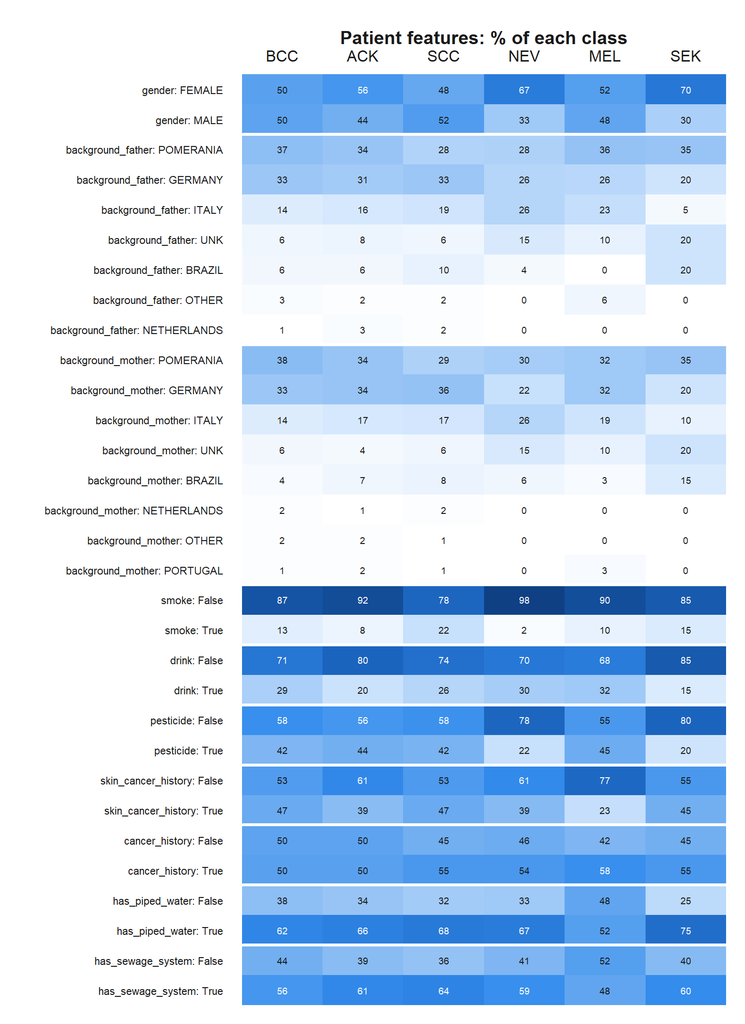

```r
heat(cat_tab[cat_tab$variable %in% patient_vars, ], "patient_features_by_class.png",
     "Patient features: % of each class")
```

Most patient features change little between classes. The clearest differences are in NEV and SEK, which have more women (67% and 70%) and fewer pesticide users (22% and 20%) than the other classes. Smoking is more common in SCC (22%) than in any other class. MEL patients report a personal or family history of skin cancer less often (23%, against 39% to 47% in the rest). Piped water, sewage system and the parents’ origin show no clear pattern. NEV, MEL and SEK have few patients, so differences of a few percentage points in those columns can be noise.

## 4.2 Lesion features

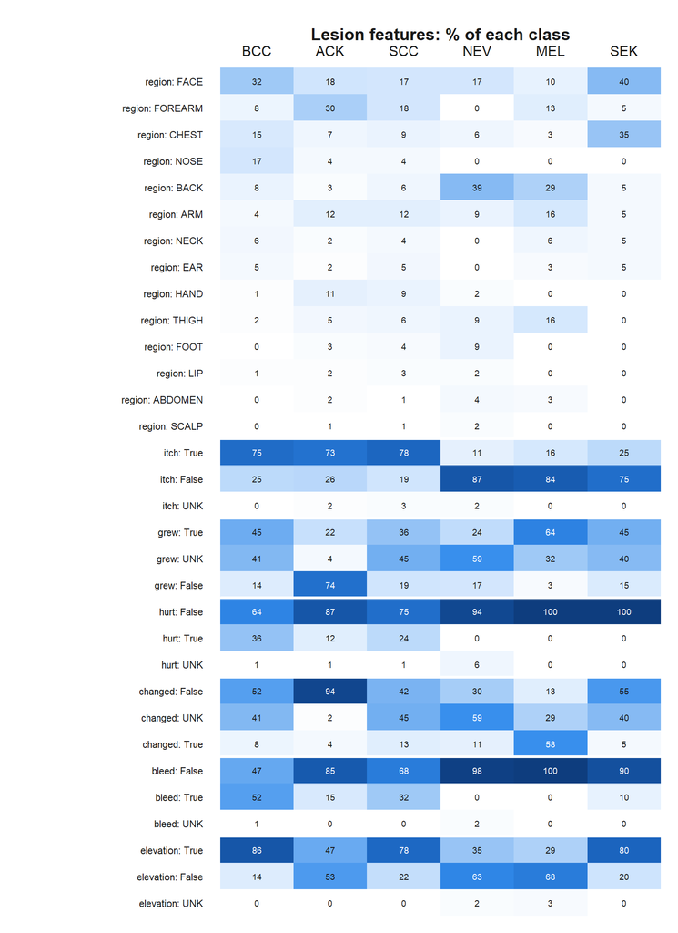

```r
heat(cat_tab[cat_tab$variable %in% lesion_vars, ], "lesion_features_by_class.png",
     "Lesion features: % of each class")
```

The lesion features differ much more between classes. NEV and MEL almost never itch, hurt or bleed, while about half of the BCC lesions bleed. BCC is mostly on the face and nose, ACK on the forearm and hands, and NEV and MEL more often on the back. MEL stands out: 64% of the lesions grew and 58% changed recently, which agrees with the usual clinical warning signs of melanoma. For grew and changed, the answer UNK is common in every class except ACK (4% and 2%). We keep UNK as its own level, but since this pattern may partly come from how the data were collected, we also check that the results do not depend on these two features.

# 5 Does each feature differ between classes?

Kruskal-Wallis for the numeric features and chi-square with a simulated p-value for the categorical ones, sorted from the strongest difference. These tests only describe the data; they are not corrected for multiple testing.

```r
tests <- rbind(
  do.call(rbind, lapply(NUM_VARS, function(v) {
    kt <- kruskal.test(d[[v]] ~ d$diagnostic)
    data.frame(variable = v, type = "numeric", test = "Kruskal-Wallis",
               statistic = round(unname(kt$statistic), 2), p_value = signif(kt$p.value, 3))
  })),
  do.call(rbind, lapply(names(cat_df), function(v) {
    ct <- chisq.test(table(cat_df[[v]], d$diagnostic), simulate.p.value = TRUE, B = 5000)
    data.frame(variable = v, type = "categorical", test = "Chi-square (simulated p)",
               statistic = round(unname(ct$statistic), 2), p_value = signif(ct$p.value, 3))
  }))
)
tests <- tests[order(tests$p_value, -tests$statistic), ]
kable(tests, row.names = FALSE)
```

| variable | type | test | statistic | p_value |
| --- | --- | --- | --- | --- |
| age | numeric | Kruskal-Wallis | 93.03 | 0.00e+00 |
| diameter_2 | numeric | Kruskal-Wallis | 41.06 | 1.00e-07 |
| diameter_1 | numeric | Kruskal-Wallis | 34.07 | 2.30e-06 |
| region | categorical | Chi-square (simulated p) | 324.60 | 2.00e-04 |
| grew | categorical | Chi-square (simulated p) | 235.53 | 2.00e-04 |
| changed | categorical | Chi-square (simulated p) | 197.71 | 2.00e-04 |
| elevation | categorical | Chi-square (simulated p) | 167.63 | 2.00e-04 |
| itch | categorical | Chi-square (simulated p) | 154.47 | 2.00e-04 |
| bleed | categorical | Chi-square (simulated p) | 128.46 | 2.00e-04 |
| hurt | categorical | Chi-square (simulated p) | 83.35 | 2.00e-04 |
| smoke | categorical | Chi-square (simulated p) | 15.82 | 8.60e-03 |
| fitspatrick | numeric | Kruskal-Wallis | 14.61 | 1.22e-02 |
| pesticide | categorical | Chi-square (simulated p) | 11.85 | 3.88e-02 |
| skin_cancer_history | categorical | Chi-square (simulated p) | 9.78 | 7.86e-02 |
| background_father | categorical | Chi-square (simulated p) | 41.22 | 9.14e-02 |
| gender | categorical | Chi-square (simulated p) | 8.89 | 1.16e-01 |
| drink | categorical | Chi-square (simulated p) | 6.47 | 2.68e-01 |
| background_mother | categorical | Chi-square (simulated p) | 37.29 | 3.57e-01 |
| has_piped_water | categorical | Chi-square (simulated p) | 5.14 | 4.07e-01 |
| has_sewage_system | categorical | Chi-square (simulated p) | 4.61 | 4.67e-01 |
| cancer_history | categorical | Chi-square (simulated p) | 1.73 | 8.88e-01 |

```r
save_tab(tests, "feature_tests.csv")
```

Age, lesion region and the lesion symptoms (grew, changed, elevation, itch, bleed, hurt) differ strongly between classes. Smoking, Fitzpatrick type and pesticide use show weaker differences, and the remaining patient features show no clear difference at the 5% level. A p-value of 2e-04 is the smallest value the simulation with 5000 replicates can give, so for those features the true p-value is even smaller. Because 21 tests are run with no correction, the borderline results (p between 0.01 and 0.05) should be read with care. Overall, most of the information is in the lesion itself and in age, which is also the kind of information an LLM can use from a text description.

# 6 Files written

```r
list.files(OUT_DIR)
```

```
## [1] "categorical_by_class.csv"      "class_counts.csv"
## [3] "class_counts.png"              "feature_tests.csv"
## [5] "lesion_features_by_class.png"  "numeric_by_class.png"
## [7] "numeric_correlation.csv"       "numeric_summary.csv"
## [9] "patient_features_by_class.png"
```